# Naiveté, Projection Bias, and Habit Formation in Gym Attendance

# Primary DiD

$Attendance_{it} = \gamma_1 \cdot During_t + \gamma_2 \cdot During_t \cdot TR_i$

$+ \gamma_3 \cdot Post_t + \gamma_4 \cdot Post_t \cdot TR_i$

$+ \gamma_5 \cdot LatePost_t + \gamma_6 \cdot LatePost_t \cdot TR_i + \mu_i + \varepsilon_it$

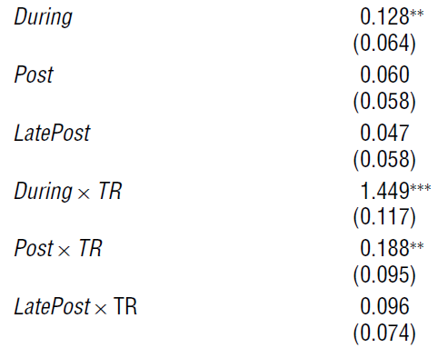

# P-Coupon DiD

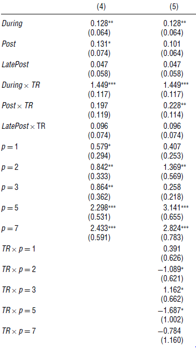

# Prediction DiD

$Prediction_{iwt} = \gamma_1 \cdot 2nd_t + \theta'P_{iw} + \mu_i + \varepsilon_{iwt}$

# Prediction DiD

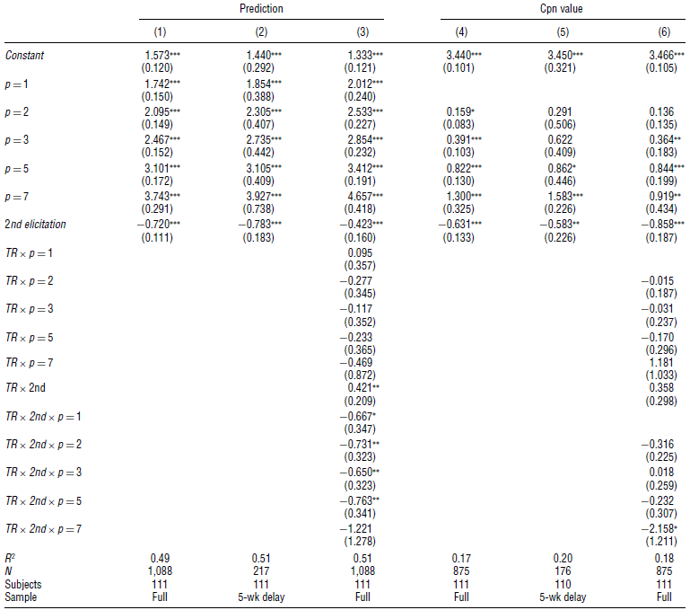

# Key takeaways

- Subjects’ WTA for additional gym visits was $2.60 when they stated it was $.16
- Explains gyms’ business models
- Contracts likely more effective than interventions

## Concerns

- Treated individuals might see the gym as “less scary” during the treatment month
- May have made friends/“social contracts”

# Discussion

- Disincentives vs incentives
- Ways of continuously measuring habit progression
- Max can tell you how to actually lose weight (hint: it’s a behavioral/mental thing)

## Appendix

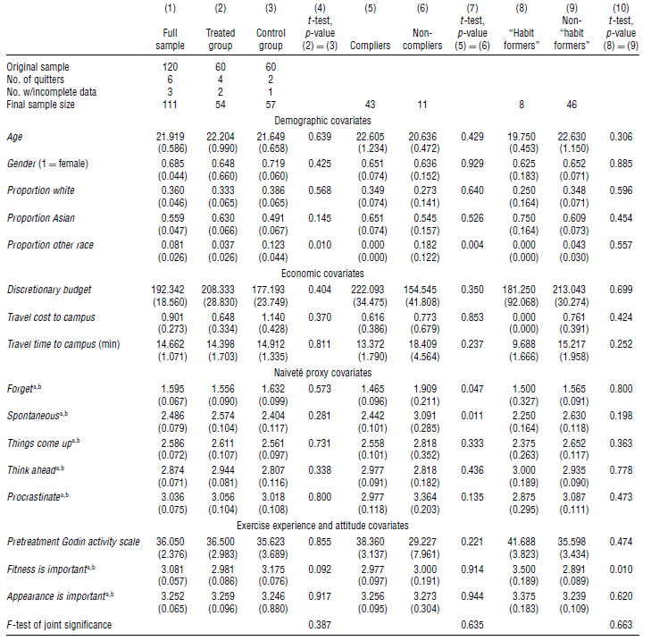